# **Chapter 04 函數 Functions**

## **儲存(並重複使用)程式步驟**

- 我們將這些可重用的程式碼稱為"函數"
- 範例

  ```
  def thing():
    print('Hello')
    print('Fun')
  thing()
  print('Zip')
  thing()
  ```

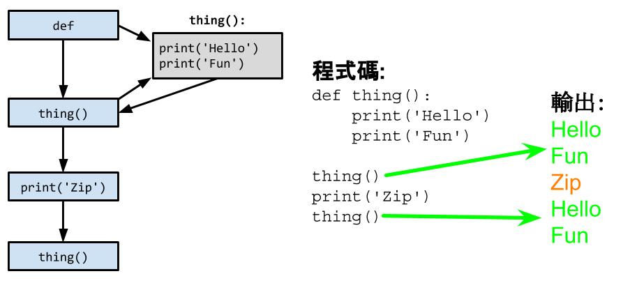

```python
def thing():
    print('Hello')
    print('Fun')

thing()
print('Zip')
thing()
```

```
Hello
Fun
Zip
Hello
Fun
```

## **Python函數類型**

- 在Python中有兩種不同的函數
  - **內建函數** (Built-in Functions)：Python預設提供
    - e.g. print(), type(), float(), int()
  - **自訂函數** (Function that we define ourselves)：我們自己寫的並且之後拿來使用
  - 我們把**內建函數視為保留字**，也就是其他變數的命名不能夠使用

## **定義函數**

- 在Python中，函數是一些可重用的程式碼，可以定義輸入的引數(arguments)，在程式碼中進行一些計算，然後從函數中回傳一個或多個結果
- 定義函數時，使用保留字**def**
- 使用函數，成為呼叫(call)或是調用(invoke)
- 呼叫函數是使用函數的名稱，並加上括號結尾，在括號中可寫下要傳入到函數中的引數(argument)

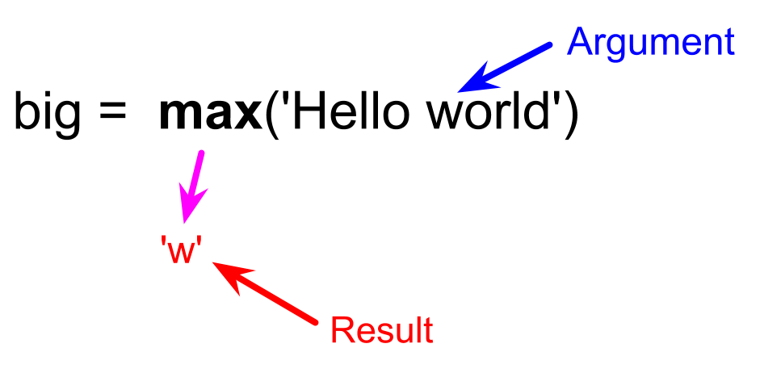

## **內建函數 Built-in Functions**

### 函數Max

- 函數是儲存我們使用的一些程式碼，函數需要一些輸入並產生輸出

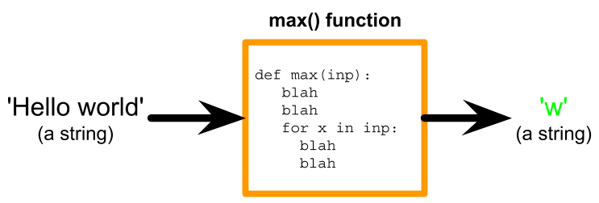

### 型態轉換 Type Conversion

- 當您將整數和浮點數放在表達式中時，該整數將偷偷的被轉換為浮點數
- 您可以使用內建函數int()和float()很明確的進行轉換

```python
print(float(99) / 100)

i = 42
print(type(i))

f = float(i)
print(f)

print(type(f))

print(1 + 2 * float(3) / 4 - 5)
```

```
0.99
<class 'int'>
42.0
<class 'float'>
-2.5
```

### 字串轉換 String Conversion

- 您也可以使用int()或float()，讓字串轉換成數字
- 當字串無法轉換成數字時，例如字串的內容不是數字，程式就會出現錯誤(error)

```python
sval = '123'
print(type(sval))

print(sval + 1)
```

```
<class 'str'>
```

```
---------------------------------------------------------------------------
TypeError                                 Traceback (most recent call last)
<ipython-input-2-4ddfe5a2c4a3> in <module>()
      2 print(type(sval))
      3
----> 4 print(sval + 1)

TypeError: must be str, not int
```

```python
sval = '123'
ival = int(sval)
print(type(ival))
print(ival + 1)
```

```
<class 'int'>
124
```

```python
nsv = 'hello bob'
niv = int(nsv)
```

```
---------------------------------------------------------------------------
ValueError                                Traceback (most recent call last)
<ipython-input-4-de8bd31b3c29> in <module>()
      1 nsv = 'hello bob'
----> 2 niv = int(nsv)

ValueError: invalid literal for int() with base 10: 'hello bob'
```

### 練習

- 使用內建函數min()找出'Hello World'的最小字是哪一個並輸出在畫面上

## **自訂函數**

### 建立自訂函數 Building our Own Functions

- 我們創建一個自訂的新函數，使用**def**關鍵字及括號，括號中的可以擺放引數 (argument)
- 函數內的程式碼，我們進行縮排(Indent)，表明程式碼是屬於函數的
- 這只是定義了一個新的函數，但在你呼叫他之前，他不會執行

```python
# 定義函數
def print_lyrics():
    print("I am a lumberjack, and I'm okay.")
    print("I sleep all night and I work all day.")
```

#### 函數在我們呼叫之前並不會正常執行

```python
x = 5
print('Hello')

# 定義函數
def print_lyrics():
    print("I am a lumberjack, and I'm okay.")
    print("I sleep all night and I work all day.")

print('Yo')
x = x + 2
print(x)
```

```
Hello
Yo
7
```

#### 呼叫定義好的函數

- 當我們定義好一個函數後，我們可以呼叫(call)或調用(invoke)函數，想呼叫幾次就幾次
- 這就是儲存並重複使用的模式 (**store and reuse pattern**)

```python
x = 5
print('Hello')

# 定義函數
def print_lyrics():
    print("I am a lumberjack, and I'm okay.")
    print("I sleep all night and I work all day.")

print('Yo')

# 呼叫函數
print_lyrics()

x = x + 2
print(x)
```

```
Hello
Yo
I am a lumberjack, and I'm okay.
I sleep all night and I work all day.
7
```

#### 練習

- 寫一個自訂函數，函數所做的事情就是印出你的姓名
- 定義完函數後，記得呼叫/調用函數使你的姓名印在畫面上

### 引數 Arguments

- 引數是我們在呼叫(call)/調用(invoke)函數時，傳遞給函數當作輸入的數值
- 我們可以在每次使用函數時，傳入不同的引數，讓函數去執行不同的工作
- 我們將引數放在函數名稱後的括號中

  ```
  big = max('Hello World')
  ```

  - 上面的程式碼，'Hello World'就是引數Argument

### 參數 Parameters

- 參數是我們在函數定義中使用的變數，它允許函數中的程式碼訪問傳遞到函數的引數(argument)

```python
def greet(lang):
    # lang是參數parameter
    if lang == 'es':
        print('Hola')
    elif lang == 'fr':
        print('Bonjour')
    else:
        print('Hello')

# 'en'是引數 argument
greet('en')

# 'es'是引數 argument
greet('es')

# 'fr'是引數 argument
greet('fr')
```

```
Hello
Hola
Bonjour
```

### 回傳值1 Return Value

- 函數通常會接受其參數，進行一些計算並返回一個值
- 這個值就是函數運算的結果，回到原本呼叫(call)/調用(invoke)函數的程式碼中
- return關鍵字就是用於此目的

```python
def greet():
    return 'Hello'

print(greet(), 'Glenn')
print(greet(), 'Sally')
```

```
Hello Glenn
Hello Sally
```

### 回傳值2 Return Value

- 一個有「產出(fruitfull)」的函數是會產生結果(或返回值)的函數
- return便結束了函數的執行，並回傳函數運作的結果

```python
def greet(lang):
    if lang == 'es':
        return 'Hola'
    elif lang == 'fr':
        return 'Bonjour'
    else:
        return 'Hello'

print(greet('en'), 'Glenn')
print(greet('es'), 'Sally')
print(greet('fr'), 'Michael')
```

```
Hello Glenn
Hola Sally
Bonjour Michael
```

### 引數Arguments、參數Parameters與回傳值Return Value

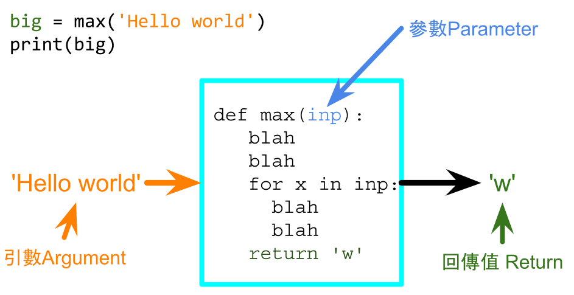

### 練習

- 定義自訂函數，參數是bmi
- 函數進行bmi判斷，如果bmi大於24.9，回傳「不健康」，反之回傳「健康」
- 記得要呼叫函數，並傳入引數，確認函數運作正常

### 多引數/參數 Multiple Arguments/Parameters

- 我們可以在函數定義中定義多個參數
- 呼叫/調用函數時，我們只需添加更多引數
- 我們要讓呼叫函數時，傳遞的引數與函數的參數數量與順序相同

```python
# 定義了兩個參數
def addtwo(a, b):
    added = a + b
    return added

# 呼叫/調用函數時，引數的順序和數量要與函數的參數相同
x = addtwo(3, 5)
print(x)
```

```
8
```

## **無產出函數 Void Function**

- 當一個函數沒有回傳值時，我們稱為Void Function
- 有回傳值的函數稱為有產出(fruitful)函數
- 沒有回傳值的函數是無產出(not fruitful)函數

## **要轉成函數/不要轉成函數**

- 將您的程式碼組織為一段一段(paragraphs)的，以便釐清完整想法並為其命名
- 別重複做同樣的事情，將程式碼處理好並能正常執行後重複使用它
- 如果有些程式碼的邏輯太長或太複雜，將程式碼的邏輯切分成較小的區段，每個區段獨立成為一個函數
- 可以為常常重複使用的程式碼建立資料庫，也許還可以與您的朋友分享

## **總結複習**

- 函數 Functions
- 內建函數 Built-In Functions
- 型態轉換 Type conversion (int, float)
- 字串轉換 String conversions
- 參數 Parameters
- 引數 Arguments
- 有回傳值函數 Results (fruitful functions)
- 無回傳值函數 Void (non-fruitful) functions
- 為何要使用函數？

## **作業**

- 寫一個程式，跳出詢問框，詢問用戶的工作時數(hours)以及時薪(rate)並計算薪資總額
- 40小時以下為正常工資，40小時以上，每小時為1.5倍工資
- 建立一個函數成為computepay()，將運算邏輯寫在此函數中
- 函數應該要回傳計算的結果
- 測試時使用工作時數45小時，時薪10.50來計算，所得結果應該為498.75
  - 提醒1：記得將用戶輸入的內容由字串轉換成浮點數
  - 提醒2：我們先假設用戶都會輸入數字而不是非數字的內容
  - 提醒3：變數的命名不要用sum，因為sum()是內建函數

# Acknowledgements / Contributions

Python For Everyone

- These slides are Copyright 2010- Charles R. Severance (www.dr-chuck.com) of the University of Michigan School of Information and made available under a Creative Commons Attribution 4.0 License. Please maintain this last slide in all copies of the document to comply with the attribution requirements of the license. If you make a change, feel free to add your name and organization to the list of contributors on this page as you republish the materials.
- Initial Development: Charles Severance, University of Michigan School of Information